$Tema:$ Modelo de análisis para predecir el total de muertes a causa del COVID-19 usando técnicas de regresion multivariante y clustering

# METODO PROPUESTO

Las librerias que se utilizaron en este analisis son: numpy, pandas, sklearn y matplotlib

## CARGA DEL DATASET

$1.$ Se procede a cargar el dataset del sitio web: https://ourworldindata.org/covid-deaths

```python
import pandas as pd
import numpy as np
df = pd.read_csv('owid-covid-data.csv', header=0)
df
```

|  | iso_code | continent | location | date | total_cases | new_cases | total_deaths | new_deaths | total_cases_per_million | new_cases_per_million | ... | aged_70_older | gdp_per_capita | extreme_poverty | cardiovasc_death_rate | diabetes_prevalence | female_smokers | male_smokers | handwashing_facilities | hospital_beds_per_thousand | life_expectancy |
| --- | --- | --- | --- | --- | --- | --- | --- | --- | --- | --- | --- | --- | --- | --- | --- | --- | --- | --- | --- | --- | --- |
| 0 | AFG | Asia | Afghanistan | 2019-12-31 | 0.0 | 0.0 | 0.0 | 0.0 | 0.0 | 0.0 | ... | 1.337 | 1803.987 | NaN | 597.029 | 9.59 | NaN | NaN | 37.746 | 0.5 | 64.83 |
| 1 | AFG | Asia | Afghanistan | 2020-01-01 | 0.0 | 0.0 | 0.0 | 0.0 | 0.0 | 0.0 | ... | 1.337 | 1803.987 | NaN | 597.029 | 9.59 | NaN | NaN | 37.746 | 0.5 | 64.83 |
| 2 | AFG | Asia | Afghanistan | 2020-01-02 | 0.0 | 0.0 | 0.0 | 0.0 | 0.0 | 0.0 | ... | 1.337 | 1803.987 | NaN | 597.029 | 9.59 | NaN | NaN | 37.746 | 0.5 | 64.83 |
| 3 | AFG | Asia | Afghanistan | 2020-01-03 | 0.0 | 0.0 | 0.0 | 0.0 | 0.0 | 0.0 | ... | 1.337 | 1803.987 | NaN | 597.029 | 9.59 | NaN | NaN | 37.746 | 0.5 | 64.83 |
| 4 | AFG | Asia | Afghanistan | 2020-01-04 | 0.0 | 0.0 | 0.0 | 0.0 | 0.0 | 0.0 | ... | 1.337 | 1803.987 | NaN | 597.029 | 9.59 | NaN | NaN | 37.746 | 0.5 | 64.83 |
| ... | ... | ... | ... | ... | ... | ... | ... | ... | ... | ... | ... | ... | ... | ... | ... | ... | ... | ... | ... | ... | ... |
| 31910 | NaN | NaN | International | 2020-02-28 | 705.0 | 0.0 | 4.0 | 0.0 | NaN | NaN | ... | NaN | NaN | NaN | NaN | NaN | NaN | NaN | NaN | NaN | NaN |
| 31911 | NaN | NaN | International | 2020-02-29 | 705.0 | 0.0 | 6.0 | 2.0 | NaN | NaN | ... | NaN | NaN | NaN | NaN | NaN | NaN | NaN | NaN | NaN | NaN |
| 31912 | NaN | NaN | International | 2020-03-01 | 705.0 | 0.0 | 6.0 | 0.0 | NaN | NaN | ... | NaN | NaN | NaN | NaN | NaN | NaN | NaN | NaN | NaN | NaN |
| 31913 | NaN | NaN | International | 2020-03-02 | 705.0 | 0.0 | 6.0 | 0.0 | NaN | NaN | ... | NaN | NaN | NaN | NaN | NaN | NaN | NaN | NaN | NaN | NaN |
| 31914 | NaN | NaN | International | 2020-03-10 | 696.0 | -9.0 | 7.0 | 1.0 | NaN | NaN | ... | NaN | NaN | NaN | NaN | NaN | NaN | NaN | NaN | NaN | NaN |

31915 rows × 34 columns

## LIMPIEZA DE DATOS

$2.$ En este punto se procede a realizar una limpieza de datos usando el comando replace para remplacar los valores NaN

```python
df['iso_code'] = df['iso_code'].replace(np.nan, 'NoIso')
df['date'] = df['date'].replace(np.nan, 'NoDate')
df['continent'] = df['continent'].replace(np.nan, 'NoContinent')
df['location'] = df['location'].replace(np.nan, 'NoLocation')
df['total_cases'] = df['total_cases'].replace(np.nan, 0)
df['new_cases'] = df['new_cases'].replace(np.nan, 0)
df['total_deaths'] = df['total_deaths'].replace(np.nan, 0)
df['new_deaths'] = df['new_deaths'].replace(np.nan, 0)
df['total_cases_per_million'] = df['total_cases_per_million'].replace(np.nan, 0)
df['new_cases_per_million'] = df['new_cases_per_million'].replace(np.nan, 0)
df['total_deaths_per_million'] = df['total_deaths_per_million'].replace(np.nan, 0)
df['new_deaths_per_million'] = df['new_deaths_per_million'].replace(np.nan, 0)
df['total_tests'] = df['total_tests'].replace(np.nan, 0)
df['new_tests'] = df['new_tests'].replace(np.nan, 0)
df['total_tests_per_thousand'] = df['total_tests_per_thousand'].replace(np.nan, 0)
df['new_tests_per_thousand'] = df['new_tests_per_thousand'].replace(np.nan, 0)
df['new_tests_smoothed'] = df['new_tests_smoothed'].replace(np.nan, 0)
df['new_tests_smoothed_per_thousand'] = df['new_tests_smoothed_per_thousand'].replace(np.nan, 0)
df['tests_units'] = df['tests_units'].replace(np.nan, 'NoTest')
df['stringency_index'] = df['stringency_index'].replace(np.nan, 0)
df['population'] = df['population'].replace(np.nan, 0)
df['population_density'] = df['population_density'].replace(np.nan, 0)
df['median_age'] = df['median_age'].replace(np.nan, 0)
df['aged_65_older'] = df['aged_65_older'].replace(np.nan, 0)
df['aged_70_older'] = df['aged_70_older'].replace(np.nan, 0)
df['gdp_per_capita'] = df['gdp_per_capita'].replace(np.nan, 0)
df['extreme_poverty'] = df['extreme_poverty'].replace(np.nan, 0)
df['cardiovasc_death_rate'] = df['cardiovasc_death_rate'].replace(np.nan, 0)
df['diabetes_prevalence'] = df['diabetes_prevalence'].replace(np.nan, 0)
df['female_smokers'] = df['female_smokers'].replace(np.nan, 0)
df['male_smokers'] = df['male_smokers'].replace(np.nan, 0)
df['handwashing_facilities'] = df['handwashing_facilities'].replace(np.nan, 0)
df['hospital_beds_per_thousand'] = df['hospital_beds_per_thousand'].replace(np.nan, 0)
df['life_expectancy'] = df['life_expectancy'].replace(np.nan, 0)
df
```

|  | iso_code | continent | location | date | total_cases | new_cases | total_deaths | new_deaths | total_cases_per_million | new_cases_per_million | ... | aged_70_older | gdp_per_capita | extreme_poverty | cardiovasc_death_rate | diabetes_prevalence | female_smokers | male_smokers | handwashing_facilities | hospital_beds_per_thousand | life_expectancy |
| --- | --- | --- | --- | --- | --- | --- | --- | --- | --- | --- | --- | --- | --- | --- | --- | --- | --- | --- | --- | --- | --- |
| 0 | AFG | Asia | Afghanistan | 2019-12-31 | 0.0 | 0.0 | 0.0 | 0.0 | 0.0 | 0.0 | ... | 1.337 | 1803.987 | 0.0 | 597.029 | 9.59 | 0.0 | 0.0 | 37.746 | 0.5 | 64.83 |
| 1 | AFG | Asia | Afghanistan | 2020-01-01 | 0.0 | 0.0 | 0.0 | 0.0 | 0.0 | 0.0 | ... | 1.337 | 1803.987 | 0.0 | 597.029 | 9.59 | 0.0 | 0.0 | 37.746 | 0.5 | 64.83 |
| 2 | AFG | Asia | Afghanistan | 2020-01-02 | 0.0 | 0.0 | 0.0 | 0.0 | 0.0 | 0.0 | ... | 1.337 | 1803.987 | 0.0 | 597.029 | 9.59 | 0.0 | 0.0 | 37.746 | 0.5 | 64.83 |
| 3 | AFG | Asia | Afghanistan | 2020-01-03 | 0.0 | 0.0 | 0.0 | 0.0 | 0.0 | 0.0 | ... | 1.337 | 1803.987 | 0.0 | 597.029 | 9.59 | 0.0 | 0.0 | 37.746 | 0.5 | 64.83 |
| 4 | AFG | Asia | Afghanistan | 2020-01-04 | 0.0 | 0.0 | 0.0 | 0.0 | 0.0 | 0.0 | ... | 1.337 | 1803.987 | 0.0 | 597.029 | 9.59 | 0.0 | 0.0 | 37.746 | 0.5 | 64.83 |
| ... | ... | ... | ... | ... | ... | ... | ... | ... | ... | ... | ... | ... | ... | ... | ... | ... | ... | ... | ... | ... | ... |
| 31910 | NoIso | NoContinent | International | 2020-02-28 | 705.0 | 0.0 | 4.0 | 0.0 | 0.0 | 0.0 | ... | 0.000 | 0.000 | 0.0 | 0.000 | 0.00 | 0.0 | 0.0 | 0.000 | 0.0 | 0.00 |
| 31911 | NoIso | NoContinent | International | 2020-02-29 | 705.0 | 0.0 | 6.0 | 2.0 | 0.0 | 0.0 | ... | 0.000 | 0.000 | 0.0 | 0.000 | 0.00 | 0.0 | 0.0 | 0.000 | 0.0 | 0.00 |
| 31912 | NoIso | NoContinent | International | 2020-03-01 | 705.0 | 0.0 | 6.0 | 0.0 | 0.0 | 0.0 | ... | 0.000 | 0.000 | 0.0 | 0.000 | 0.00 | 0.0 | 0.0 | 0.000 | 0.0 | 0.00 |
| 31913 | NoIso | NoContinent | International | 2020-03-02 | 705.0 | 0.0 | 6.0 | 0.0 | 0.0 | 0.0 | ... | 0.000 | 0.000 | 0.0 | 0.000 | 0.00 | 0.0 | 0.0 | 0.000 | 0.0 | 0.00 |
| 31914 | NoIso | NoContinent | International | 2020-03-10 | 696.0 | -9.0 | 7.0 | 1.0 | 0.0 | 0.0 | ... | 0.000 | 0.000 | 0.0 | 0.000 | 0.00 | 0.0 | 0.0 | 0.000 | 0.0 | 0.00 |

31915 rows × 34 columns

## MEDIDAS DE CALIDAD

$3.$ En esta parte encontramos las varianza y la media de las variables de casos y muertes por covid-19.

Para obtener la media usamos el comando mean y para la varianza el comando var

```python
import statistics as stats
df['total_cases'] = df['total_cases']
df['total_deaths'] = df['total_deaths']
print("Media de Casos por Covid-19: " + str(stats.mean(df['total_cases'])))
print("Media de Muertes por Covid-19: " + str(stats.mean(df['total_deaths'])))
print("Varianza de casos: " + str(df['total_cases'].var()))
print("Varianza de muertes: " + str(df['total_deaths'].var()))
```

```
Media de Casos por Covid-19: 45734.80360332132
Media de Muertes por Covid-19: 2468.4121886260377
Varianza de casos: 216501321431.14407
Varianza de muertes: 561568357.140213
```

$4.$ Aqui realizamos los mapas de calor correspondientes a las correlacion de todas las variables que existen en el dataset, despues se utiliza el mismo comando cor para graficar el mapa de calor pero de la correlacion de en cuanto al campo de total de muertes.

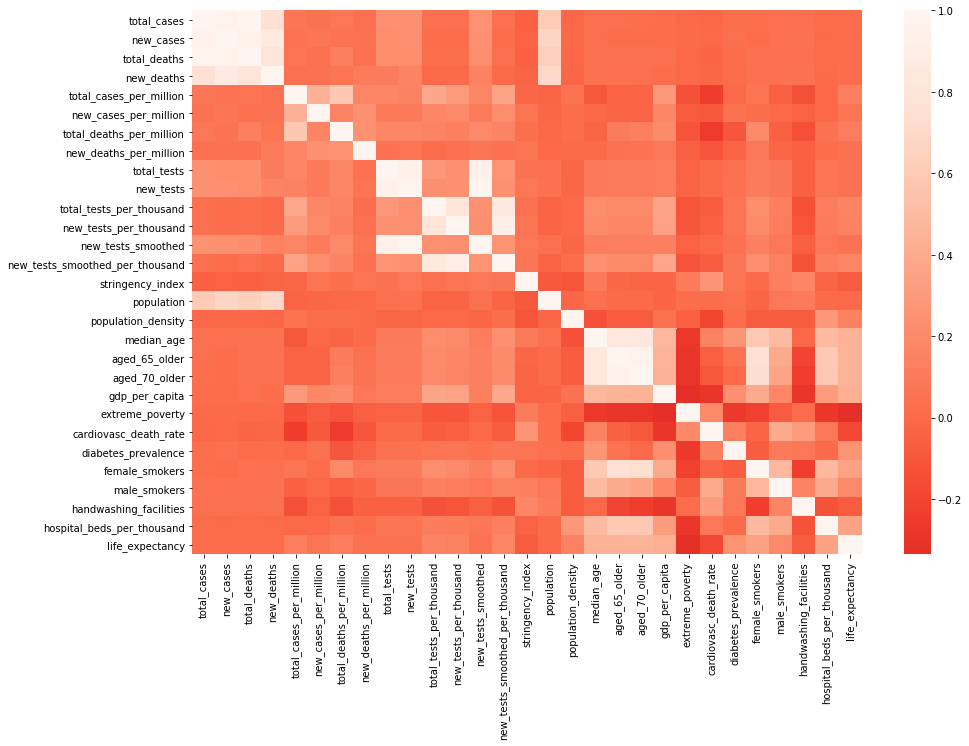

```python
import seaborn as sns
from matplotlib import pyplot as plt
df_cor = df.corr()
plt.figure(figsize = (15,10))
sns.heatmap(df_cor, center=0, cmap='Reds_r', annot=False)
```

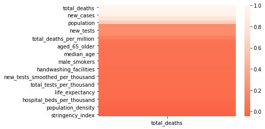

```python
df_cord = pd.DataFrame(df.corr()['total_deaths'].sort_values(ascending=False))
df_cord
sns.heatmap(df_cord, center=0, cmap='Reds_r', annot=False)
```

## AGRUPAMIENTO DE DATOS

$5.$ EL siguiente paso es agrupar las variables que necesitamos descartando las inecesarias usando el metodo drop para eliminarlas (no se quitaran del dataset, sino que se eliminaran en el cuaderno en memoria).

El metodo groupby necesita de la media de cada columna para comprimir todos los datos de la misma variable en una sola. Cabe mencionar que nuestro dataset ("datasetAgrupado.csv") que creamos con el comando to_csv cuenta con los datos agrupados y con la media de cada uno de ellos

```python
eliminacion = df.drop(['iso_code','continent','date','tests_units','new_cases','new_deaths','total_cases_per_million','new_cases_per_million','total_deaths_per_million','new_deaths_per_million','total_tests','new_tests','total_tests_per_thousand','new_tests_per_thousand','new_tests_smoothed','new_tests_smoothed_per_thousand','stringency_index','population','population_density','median_age','aged_65_older','aged_70_older','gdp_per_capita','extreme_poverty','cardiovasc_death_rate','diabetes_prevalence','female_smokers','male_smokers','handwashing_facilities','hospital_beds_per_thousand','life_expectancy'], axis=1)
agrupamiento = eliminacion.groupby(['total_deaths']).mean()
agrupamiento = eliminacion.groupby(['total_cases']).mean()
agrupamiento = eliminacion.groupby(['location']).mean()
agrupamiento.to_csv("datasetAgrupado.csv", sep=",",index = True) #sep es el separado, por defector es ","
agrupamiento = pd.read_csv('datasetAgrupado.csv', header=0)
agrupamiento
```

|  | location | total_cases | total_deaths |
| --- | --- | --- | --- |
| 0 | Afghanistan | 8.824621e+03 | 214.241026 |
| 1 | Albania | 1.242647e+03 | 36.213235 |
| 2 | Algeria | 5.102785e+03 | 355.475000 |
| 3 | Andorra | 6.799771e+02 | 39.000000 |
| 4 | Angola | 1.394553e+02 | 6.910569 |
| ... | ... | ... | ... |
| 207 | Western Sahara | 1.692273e+02 | 0.613636 |
| 208 | World | 3.560968e+06 | 192216.673171 |
| 209 | Yemen | 5.494135e+02 | 143.105769 |
| 210 | Zambia | 8.429921e+02 | 15.158730 |
| 211 | Zimbabwe | 2.961129e+02 | 5.572581 |

212 rows × 3 columns

$6.$ Cuando agrupamos las variables se necesita tener una variable de salida de la cual escogimos el total de muertes asignada a la variable y para su posterior procesamiento.

```python
Xsubset = agrupamiento[['location','total_cases','total_deaths']]
y = df.total_deaths.values
Xsubset
```

|  | location | total_cases | total_deaths |
| --- | --- | --- | --- |
| 0 | Afghanistan | 8.824621e+03 | 214.241026 |
| 1 | Albania | 1.242647e+03 | 36.213235 |
| 2 | Algeria | 5.102785e+03 | 355.475000 |
| 3 | Andorra | 6.799771e+02 | 39.000000 |
| 4 | Angola | 1.394553e+02 | 6.910569 |
| ... | ... | ... | ... |
| 207 | Western Sahara | 1.692273e+02 | 0.613636 |
| 208 | World | 3.560968e+06 | 192216.673171 |
| 209 | Yemen | 5.494135e+02 | 143.105769 |
| 210 | Zambia | 8.429921e+02 | 15.158730 |
| 211 | Zimbabwe | 2.961129e+02 | 5.572581 |

212 rows × 3 columns

## PREPROCESAMIENTO

$7.$ Este paso es necesario realizarlo, ya que el metodo de preprocesamiento nos ayuda a combinar las variables categoricas con las numericas.

Para transformar las categoricas a numericas se utiliza el metodo OneHotEncoder, y para separar las numericsa se utiliza el SantardScale, esto se realiza debido a que ciertos campos de texto no se van a correlacionar con campos numericos, y viceversa un numerico no se puede correlacionar con un texto.

```python
from sklearn.preprocessing import StandardScaler
from sklearn.preprocessing import OneHotEncoder
from sklearn.compose import make_column_transformer
#PRIMERA FORMA DE PREPROCESAR

preprocesador1 = make_column_transformer(
    (StandardScaler(),['total_cases','total_deaths']),
   (OneHotEncoder(),['location']),)

XProcesado = preprocesador1.fit_transform(Xsubset)

categorical_features = ['location']
cnamesDataset1 = ['total_cases','total_deaths']
cnamesDataset2 = preprocesador1.transformers_[1][1].get_feature_names(categorical_features)

cnamesDataset1.extend(cnamesDataset2)
print(cnamesDataset1)
cnamesDataset1 = np.array(cnamesDataset1)

DatasetPreprocesado = pd.DataFrame(XProcesado.toarray(),columns=cnamesDataset1)

DatasetPreprocesado.to_csv("datasetPreprocesado.csv", sep=";",index = False) #sep es el separado, por defector es ","
DatasetPreprocesado.head()
```

```
['total_cases', 'total_deaths', 'location_Afghanistan', 'location_Albania', 'location_Algeria', 'location_Andorra', 'location_Angola', 'location_Anguilla', 'location_Antigua and Barbuda', 'location_Argentina', 'location_Armenia', 'location_Aruba', 'location_Australia', 'location_Austria', 'location_…
```

|  | total_cases | total_deaths | location_Afghanistan | location_Albania | location_Algeria | location_Andorra | location_Angola | location_Anguilla | location_Antigua and Barbuda | location_Argentina | ... | location_Uruguay | location_Uzbekistan | location_Vatican | location_Venezuela | location_Vietnam | location_Western Sahara | location_World | location_Yemen | location_Zambia | location_Zimbabwe |
| --- | --- | --- | --- | --- | --- | --- | --- | --- | --- | --- | --- | --- | --- | --- | --- | --- | --- | --- | --- | --- | --- |
| 0 | -0.102642 | -0.118616 | 1.0 | 0.0 | 0.0 | 0.0 | 0.0 | 0.0 | 0.0 | 0.0 | ... | 0.0 | 0.0 | 0.0 | 0.0 | 0.0 | 0.0 | 0.0 | 0.0 | 0.0 | 0.0 |
| 1 | -0.132453 | -0.131559 | 0.0 | 1.0 | 0.0 | 0.0 | 0.0 | 0.0 | 0.0 | 0.0 | ... | 0.0 | 0.0 | 0.0 | 0.0 | 0.0 | 0.0 | 0.0 | 0.0 | 0.0 | 0.0 |
| 2 | -0.117276 | -0.108347 | 0.0 | 0.0 | 1.0 | 0.0 | 0.0 | 0.0 | 0.0 | 0.0 | ... | 0.0 | 0.0 | 0.0 | 0.0 | 0.0 | 0.0 | 0.0 | 0.0 | 0.0 | 0.0 |
| 3 | -0.134665 | -0.131357 | 0.0 | 0.0 | 0.0 | 1.0 | 0.0 | 0.0 | 0.0 | 0.0 | ... | 0.0 | 0.0 | 0.0 | 0.0 | 0.0 | 0.0 | 0.0 | 0.0 | 0.0 | 0.0 |
| 4 | -0.136791 | -0.133690 | 0.0 | 0.0 | 0.0 | 0.0 | 1.0 | 0.0 | 0.0 | 0.0 | ... | 0.0 | 0.0 | 0.0 | 0.0 | 0.0 | 0.0 | 0.0 | 0.0 | 0.0 | 0.0 |

5 rows × 214 columns

## ESTANDARIZACIÓN

$8.$ Para los normalizar los datos del dtaset preprocesado se necesita realizar una nomalizacion a traves del metodo StandarScaler que ayuda a tener un agrupamiento fijo.

```python
#Estandarizacion
from sklearn.preprocessing import StandardScaler
x=DatasetPreprocesado
x=StandardScaler().fit_transform(x)
x
```

```
array([[-0.1026423 , -0.11861563, 14.52583905, ..., -0.06884284,
        -0.06884284, -0.06884284],
       [-0.13245301, -0.13155919, -0.06884284, ..., -0.06884284,
        -0.06884284, -0.06884284],
       [-0.11727577, -0.10834718, -0.06884284, ..., -0.06884284,
        -0.06884284, -0.06884284],
       ...,
       [-0.13517865, -0.12378754, -0.06884284, ..., 14.52583905,
        -0.06884284, -0.06884284],
       [-0.13402437, -0.13308996, -0.06884284, ..., -0.06884284,
        14.52583905, -0.06884284],
       [-0.13617458, -0.13378692, -0.06884284, ..., -0.06884284,
        -0.06884284, 14.52583905]])
```

## REDUCCION DE DIMENSIONALIDAD

```python
#Reducción de Dimensionalidad con PCA: un dataset con menores dimensiones necesita menos costo computacional (CPU) y memoria.
from sklearn.decomposition import PCA

#Si no se especifica el número de componentes en PCA, se intenta con todas las características del dataset.
#num_components = 2
pca = PCA()
principalComponents = pca.fit_transform(x)
principalComponents

#La varianza explicada dice cuanta información (varianza) puede ser obtenida a cada componente principal.
num_components=principalComponents.shape[1]
explained_variance_ratio_=pca.explained_variance_ratio_
explained_variance_ratio_

print(explained_variance_ratio_.sum())

a = range(num_components)
num_pc= a[::1]

principalDf = pd.DataFrame(data = principalComponents
             , columns = num_pc)
principalDf=round(principalDf, 2)
print(principalDf)
```

```
1.0
       0     1      2     3     4     5     6     7     8     9    ...   202  \
0    -0.19 -0.13  14.10 -0.00  0.00 -0.00 -0.00  0.00 -0.00 -0.00  ... -0.00
1    -0.23  0.01  -0.15 -3.14 -1.87 -1.78 -0.82  0.44  0.08  0.53  ...  0.13
2    -0.20  0.07  -0.11 -0.64 -1.45  0.14  0.20 -1.12 -0.14  0.81  ...  0.01
3    -0.23  0.03  -0.11  1.96  7.38 -3.89 -2.03 -1.35 -0.89  5.81  ...  0.03
4    -0.23  0.03  -0.11 -0.08 -5.10 -0.65  1.72 -4.02 -0.11  2.31  ...  0.11
..     ...   ...    ...   ...   ...   ...   ...   ...   ...   ...  ...   ...
207  -0.23  0.02   0.02  0.32 -0.12  0.35  0.05  0.71  0.14  0.38  ... -2.30
208  24.03 -0.19  -0.55  0.15  0.04 -0.07  0.11 -0.01  0.08  0.12  ... -0.09
209  -0.22  0.10   0.03 -0.07 -0.33  0.11  0.21  0.14  0.92 -0.03  ...  0.88
210  -0.23  0.01   0.03 -0.10 -0.74 -0.44 -0.41 -0.13  0.15 -0.54  ... -2.86
211  -0.23  0.02   0.02 -0.27 -0.65  0.01  0.07  0.24 -0.33  0.96  ... -3.02

      203   204   205   206   207   208   209   210  211
0    0.00 -0.00  0.00 -3.62 -0.00 -0.00 -0.00 -0.00  0.0
1    0.09  0.36 -0.14 -0.29 -0.72 -0.15 -0.11  0.01  0.0
2    0.02 -0.03  0.04 -0.16 -0.08  0.00 -0.09 -0.03  0.0
3    0.00  0.03 -0.05 -0.16  0.13  0.01 -0.25 -0.08  0.0
4   -0.12 -0.08  0.10 -0.16 -0.23 -0.04 -0.18 -0.13  0.0
..    ...   ...   ...   ...   ...   ...   ...   ...  ...
207  0.04 -0.57 -1.18  0.35  3.34 -1.47 -3.80 -1.13  0.0
208 -0.10  0.03  0.07 -2.29 -0.38 -0.06 -0.11 -0.11  0.0
209 -0.27  0.10 -1.00  0.39  2.30  0.07 -3.16  7.67  0.0
210  0.35  0.04  0.87  0.39 -5.08  0.51 -0.69 -0.27  0.0
211  0.15 -0.21  0.47  0.36  0.04  0.26  3.67  0.31  0.0

[212 rows x 212 columns]
```

## CLUSTERING

$10.$ Aqui se realiza el metodo del clustering para determinar cuales son los mejores grupos, y determinar los centroides.

Dentro de este proceso es necesario utilizar un metodo propio del kmeans para determinar los centroides del grupo de datos.

```python
#Metodo Elbow
from sklearn.decomposition import PCA
from sklearn.cluster import KMeans
from scipy.spatial.distance import cdist
X=principalDf
K_range=range(1,20,1)
distortions=[]

for i in K_range:
    kmeanModel = KMeans(n_clusters=i,init='k-means++')
    kmeanModel.fit(X)
    distortions.append(sum(np.min(cdist(X, kmeanModel.cluster_centers_, 'euclidean'),axis=1)) / X.shape[0])

print('Kmeans terminado')
```

```
Kmeans terminado
```

```python
#Datamining: Clustering (método no supervisado de Machine Learning)
import matplotlib.pyplot as plt
from mpl_toolkits.mplot3d import Axes3D
from sklearn import datasets
nclust=20
#Kmeans Clustering
def doKmeans(X, nclust, init='k-means++',max_iter=100, tol=0.0001, random_state=10, algorithm='full'):
    model = KMeans(nclust)
    model.fit(X)
    clust_labels = model.predict(X)
    cent = model.cluster_centers_
    return (clust_labels, cent)

clust_labels, cent = doKmeans(principalDf, nclust, init='k-means++',max_iter=100, tol=0.0001, random_state=10, algorithm='full' )
#kmeans = pd.DataFrame(clust_labels)
kmeans = pd.DataFrame(clust_labels,columns=['Grupos'])
#kmeans
print('Usuarios agrupados')
```

```
Usuarios agrupados
```

```python
kmeans
UserGrupoK=kmeans.groupby(kmeans.Grupos).Grupos.count()

UserGrupoK=UserGrupoK.sort_values(ascending=False, inplace=False, kind='quicksort')
#UserGrupoK.sort_values(by='values', axis=1, ascending=False, inplace=False, kind='quicksort')
UserGrupoK
```

```
Grupos
9     40
15    24
11    21
2     20
19    19
18    14
14    12
1     12
4      9
13     7
3      7
12     5
5      5
0      5
6      4
8      3
16     2
10     1
7      1
17     1
Name: Grupos, dtype: int64
```

## REGRESION MULTILINEAL

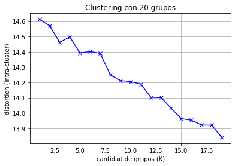

```python
# Plot the elbow
plt.plot(K_range, distortions, 'bx-')
plt.xlabel('cantidad de grupos (K)')
plt.ylabel('distortion (intra-cluster)')
plt.title('Clustering con ' + str(nclust) +  ' grupos')
plt.grid(True)
plt.show()
```

```python
df_cor1 = pd.DataFrame(x).corr()
df_cor1
```

|  | 0 | 1 | 2 | 3 | 4 | 5 | 6 | 7 | 8 | 9 | ... | 204 | 205 | 206 | 207 | 208 | 209 | 210 | 211 | 212 | 213 |
| --- | --- | --- | --- | --- | --- | --- | --- | --- | --- | --- | --- | --- | --- | --- | --- | --- | --- | --- | --- | --- | --- |
| 0 | 1.000000 | 0.992732 | -0.007066 | -0.009118 | -0.008074 | -0.009271 | -0.009417 | -0.009454 | -0.009446 | -0.002697 | ... | -0.009273 | -0.008268 | -0.009452 | -0.008781 | -0.009404 | -0.009409 | 0.954412 | -0.009306 | -0.009227 | -0.009375 |
| 1 | 0.992732 | 1.000000 | -0.008166 | -0.009057 | -0.007459 | -0.009043 | -0.009204 | -0.009238 | -0.009226 | -0.006331 | ... | -0.009152 | -0.009149 | -0.009238 | -0.009112 | -0.009238 | -0.009235 | 0.952852 | -0.008522 | -0.009162 | -0.009210 |
| 2 | -0.007066 | -0.008166 | 1.000000 | -0.004739 | -0.004739 | -0.004739 | -0.004739 | -0.004739 | -0.004739 | -0.004739 | ... | -0.004739 | -0.004739 | -0.004739 | -0.004739 | -0.004739 | -0.004739 | -0.004739 | -0.004739 | -0.004739 | -0.004739 |
| 3 | -0.009118 | -0.009057 | -0.004739 | 1.000000 | -0.004739 | -0.004739 | -0.004739 | -0.004739 | -0.004739 | -0.004739 | ... | -0.004739 | -0.004739 | -0.004739 | -0.004739 | -0.004739 | -0.004739 | -0.004739 | -0.004739 | -0.004739 | -0.004739 |
| 4 | -0.008074 | -0.007459 | -0.004739 | -0.004739 | 1.000000 | -0.004739 | -0.004739 | -0.004739 | -0.004739 | -0.004739 | ... | -0.004739 | -0.004739 | -0.004739 | -0.004739 | -0.004739 | -0.004739 | -0.004739 | -0.004739 | -0.004739 | -0.004739 |
| ... | ... | ... | ... | ... | ... | ... | ... | ... | ... | ... | ... | ... | ... | ... | ... | ... | ... | ... | ... | ... | ... |
| 209 | -0.009409 | -0.009235 | -0.004739 | -0.004739 | -0.004739 | -0.004739 | -0.004739 | -0.004739 | -0.004739 | -0.004739 | ... | -0.004739 | -0.004739 | -0.004739 | -0.004739 | -0.004739 | 1.000000 | -0.004739 | -0.004739 | -0.004739 | -0.004739 |
| 210 | 0.954412 | 0.952852 | -0.004739 | -0.004739 | -0.004739 | -0.004739 | -0.004739 | -0.004739 | -0.004739 | -0.004739 | ... | -0.004739 | -0.004739 | -0.004739 | -0.004739 | -0.004739 | -0.004739 | 1.000000 | -0.004739 | -0.004739 | -0.004739 |
| 211 | -0.009306 | -0.008522 | -0.004739 | -0.004739 | -0.004739 | -0.004739 | -0.004739 | -0.004739 | -0.004739 | -0.004739 | ... | -0.004739 | -0.004739 | -0.004739 | -0.004739 | -0.004739 | -0.004739 | -0.004739 | 1.000000 | -0.004739 | -0.004739 |
| 212 | -0.009227 | -0.009162 | -0.004739 | -0.004739 | -0.004739 | -0.004739 | -0.004739 | -0.004739 | -0.004739 | -0.004739 | ... | -0.004739 | -0.004739 | -0.004739 | -0.004739 | -0.004739 | -0.004739 | -0.004739 | -0.004739 | 1.000000 | -0.004739 |
| 213 | -0.009375 | -0.009210 | -0.004739 | -0.004739 | -0.004739 | -0.004739 | -0.004739 | -0.004739 | -0.004739 | -0.004739 | ... | -0.004739 | -0.004739 | -0.004739 | -0.004739 | -0.004739 | -0.004739 | -0.004739 | -0.004739 | -0.004739 | 1.000000 |

214 rows × 214 columns

```python
df_cord1 = pd.DataFrame(DatasetPreprocesado.corr()['total_deaths'].sort_values(ascending=False))
df_cord1[:22]
```

|  | total_deaths |
| --- | --- |
| total_deaths | 1.000000 |
| total_cases | 0.992732 |
| location_World | 0.952852 |
| location_United States | 0.235051 |
| location_United Kingdom | 0.081315 |
| location_Italy | 0.076147 |
| location_Brazil | 0.074346 |
| location_France | 0.060720 |
| location_Spain | 0.060370 |
| location_Mexico | 0.026706 |
| location_Belgium | 0.013657 |
| location_Iran | 0.013507 |
| location_India | 0.013365 |
| location_Germany | 0.010497 |
| location_Peru | 0.010245 |
| location_Turkey | 0.007289 |
| location_China | 0.006568 |
| location_Canada | 0.006345 |
| location_Netherlands | 0.005008 |
| location_Russia | 0.003998 |
| location_Sweden | 0.000883 |
| location_Chile | 0.000384 |

$12.$ Este es el ultimo paso para el proceso que llevamos a cabo

Para coraborar que el analisis que hemos aplicado tiene respuestas correctas la tecnica que utilizamos fue regresion multivariante en la cual se tiene las variables de de entrenamiento y de prueba que son tuplas que se vana comprar utilizando la media estadistica para obtener el error entre ellas.

```python
X = DatasetPreprocesado.drop('total_deaths', 1)
y = DatasetPreprocesado['total_deaths']
```

```python
from sklearn.model_selection import train_test_split

X_train, X_test, y_train, y_test = train_test_split(X, y, test_size=0.2, random_state=0)
print(X_train.shape)
print(X_test.shape)
print(y_train.shape)
print(y_test.shape)
print(X_test)
```

```
(169, 213)
(43, 213)
(169,)
(43,)
     total_cases  location_Afghanistan  location_Albania  location_Algeria  \
206    -0.136605                   0.0               0.0               0.0
37     -0.136879                   0.0               0.0               0.0
89     -0.133307                   0.0               0.0               0.0
190    -0.137264                   0.0               0.0               0.0
149    -0.137309                   0.0               0.0               0.0
75     -0.136777                   0.0               0.0               0.0
96     -0.136235                   0.0               0.0               0.0
137    -0.044729                   0.0               0.0               0.0
5      -0.137327                   0.0               0.0               0.0
83     -0.133644                   0.0               0.0               0.0
```

[output cut: 260 more lines]

```python
#Training
from sklearn.linear_model import LinearRegression
regressor = LinearRegression()

regressor.fit(X_train, y_train)
#El modelo de regresión intenta encontrar los coeficientes más óptimos para todos los atributos.
coeff_df = pd.DataFrame(regressor.coef_, X.columns, columns=['Coefficient'])
coeff_df
```

|  | Coefficient |
| --- | --- |
| total_cases | 0.808339 |
| location_Afghanistan | -0.021610 |
| location_Albania | -0.010457 |
| location_Algeria | 0.000487 |
| location_Andorra | -0.008466 |
| ... | ... |
| location_Western Sahara | -0.009633 |
| location_World | 0.000000 |
| location_Yemen | -0.000482 |
| location_Zambia | -0.010717 |
| location_Zimbabwe | 0.000000 |

213 rows × 1 columns

```python
#Predicciones
y_pred = regressor.predict(X_test)
```

```python
#Comparacion Manual
datasetPreprocesado = pd.DataFrame({'Actual': y_test, 'Predicted': y_pred})
datasetPreprocesado
```

|  | Actual | Predicted |
| --- | --- | --- |
| 206 | -0.134192 | -0.124459 |
| 37 | -0.134120 | -0.124680 |
| 89 | -0.133811 | -0.121793 |
| 190 | -0.134192 | -0.124991 |
| 149 | -0.134192 | -0.125028 |
| 75 | -0.134192 | -0.124598 |
| 96 | -0.132917 | -0.124160 |
| 137 | 0.072740 | -0.050192 |
| 5 | -0.134192 | -0.125043 |
| 83 | -0.133504 | -0.122065 |
| 55 | -0.134192 | -0.125001 |
| 143 | -0.134053 | -0.124982 |
| 158 | 0.058076 | 0.505185 |
| 112 | -0.132527 | -0.123936 |
| 74 | -0.130893 | -0.099347 |
| 200 | 3.414317 | 2.965231 |
| 126 | 0.387924 | 0.071282 |
| 12 | -0.129842 | -0.109689 |
| 168 | -0.134192 | -0.124985 |
| 156 | -0.131972 | -0.034536 |
| 166 | -0.131098 | -0.115925 |
| 198 | -0.125919 | -0.073780 |
| 208 | 13.840971 | 11.192478 |
| 187 | -0.131073 | -0.112106 |
| 182 | -0.133864 | -0.123819 |
| 18 | 0.198374 | -0.030415 |
| 211 | -0.133787 | -0.124111 |
| 15 | -0.083414 | 0.042555 |
| 86 | -0.116698 | -0.100770 |
| 71 | -0.134093 | -0.124966 |
| 7 | -0.091969 | -0.045705 |
| 63 | -0.131604 | -0.118239 |
| 141 | -0.130947 | -0.122606 |
| 97 | -0.123940 | -0.089076 |
| 136 | -0.133700 | -0.116224 |
| 160 | -0.134192 | -0.125007 |
| 33 | -0.134192 | -0.124795 |
| 152 | -0.098194 | -0.085416 |
| 90 | 0.194140 | 0.384337 |
| 189 | -0.132000 | -0.119463 |
| 106 | -0.126806 | -0.081897 |
| 178 | 0.876931 | 0.279743 |
| 139 | -0.133452 | -0.123008 |

```python
#Evaluación
from sklearn import metrics
print('Mean Absolute Error:', metrics.mean_absolute_error(y_test, y_pred))
print('Mean Squared Error:', metrics.mean_squared_error(y_test, y_pred))
print('Root Mean Squared Error:', np.sqrt(metrics.mean_squared_error(y_test, y_pred)))
```

```
Mean Absolute Error: 0.13373741142399884
Mean Squared Error: 0.18639442464710487
Root Mean Squared Error: 0.43173420601928786
```